# The Relationship between Age at which Adolescents Engage in Risky Behaviors and it’s Effect on their Well-Being

Carrie Magee, Abhimanyu Barun, Ambar Pathak, and Kismat Khatri

```r
dataset = read.csv("../sadc_df.csv") # Importing the dataset
myvars <- c("Age_Alc", "Age_Weed","multiple_partners","physical_activity","Hrs_Sleep","age_sex","race","gender","fight","suicide")
data <- dataset[myvars]# creating the data frame with the selected variables
data <- data[data$age_sex != 0,]
```

## Introduction

Adolescence is a crucial life period marked by many different physical, emotional, social, academic, and interpersonal changes. The attitudes and behaviors that are developed in adolescence tend to influence the trajectory of our lives into young adulthood and beyond which makes it such a compelling area of research. With data collected from the *CDC’s Youth Risk Behavior Surveillance System (YRBSS)*, our project explores the questions **“Does the age at which adolescents start engaging in”risky” behaviors predict their interpersonal, physical, and mental well-being?** **Furthermore, how does race influence interpersonal, physical, and mental well-being?”**

We conceptualized and measured risky behaviors using the age when individuals started drinking alcohol, smoking marijuana, and having romantic relationships. Considering the objective of the project to explore risky behaviors in early adolescence, we discarded any responses that reported never engaging in any risky behaviors. The resulting ages ranged between 8 years and 13 years old.

Interpersonal, physical, and mental well-being were explored using amount of physical activity, hours of sleep per night, number of sexual partners, thoughts of suicide, and whether or not individuals have ever engaged in a fight with another person. More specifically, physical activity was measured with the question “During the past 7 days, on how many days were you physically active for a total of at least 60 minutes per day?” with responses ranging from 0 to 7 days. Sexual partners was measured by asking “With how many people have you ever had sexual intercourse?” with answers ranging from 1 to 6 people. For hours of the sleep, the question stated “On an average school night, how many hours of sleep do you get?” and answers ranged from 4 hours to 10 hours. Lastly, suicidal thoughts and fighting were binary coded (yes/no) and asked “Have you ever seriously thought about killing yourself?” and “Have you ever been in a physical fight?”

Through our analysis, we hope to understand how engaging in risky behaviors either earlier or later in adolescence may predict future interpersonal, physical, and mental well-being for youth. We hope to expand understanding about how risky behaviors can impact the way in which youth function in the various realms of everyday life and uncover any patterns that can lead to future prevent efforts for adolescents.

## Exploratory Data Analysis

Dataset Source: https://www.cdc.gov/healthyyouth/data/yrbs/index.htm

```r
# converting specific columns to factors
data$gender <- as.factor(data$gender)
data$race <- as.factor(data$race)
```

```r
# Recoding specific columns

data$fight <- recode(data$fight, '0' = 'yes', '1' = 'no')
data$suicide <- recode(data$suicide, '0' = 'yes', '1' = 'no')

# Subsets to make EDA easier
no_suicide <- subset(data, suicide == 'no')
yes_suicide <- subset(data, suicide == 'yes')

no_fight<- subset(data, fight == 'no')
yes_fight <- subset(data, fight == 'yes')
```

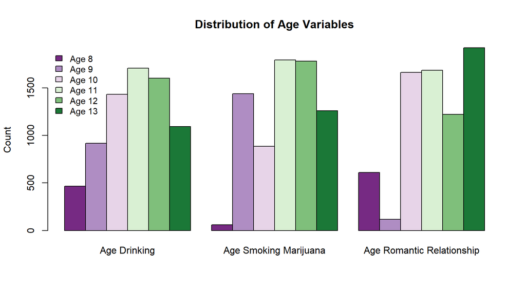

```r
# Distribution of Age for 3 different variables

library(RColorBrewer)
df <- data.frame(age_count=c("8","9","10","11","12","13"),
             count_alc=c(467,918,1434,1707,1604,1094),
             count_weed=c(61,1439,887,1796,1781,1260),
             count_sex=c(609,118,1665,1687,1222,1923))

barplot1=df$count_alc
barplot2=df$count_weed
barplot3=df$count_sex
data1 <- data.frame(barplot1,barplot2,barplot3)
 names(data1) <- c("Age Drinking","Age Smoking Marijuana","Age Romantic Relationship")

# Barplot with colors. Make sure that the plot and legends have same colors for items.
barplot(height=as.matrix(data1), main="Distribution of Age Variables", ylab="Count", beside=TRUE,
                                                            col=brewer.pal(6, "PRGn"))

# Adding legends
legend("topleft", c("Age 8","Age 9","Age 10","Age 11","Age 12","Age 13"), cex=0.9, bty="n",
                                                             fill=brewer.pal(6, "PRGn"))
```

This graph on the far left illustrates the number of respondents who started drinking alcohol between the ages of 8 years and 13 years old. We observe that most respondents started drinking when they were around the ages 10 to 12 years old.The second graph illustrates the number of respondents who smoked marijuana for the first time during the of 8 and 13 years old. We observe that few respondents started smoking Marijuana as early as at 8 years. A majority of individuals started smoking marijuana around the ages of 11 and 12 years old. Lastly, the graph on the right depicts individuals ages when they had their first romantic experience and we see that most respondents had their first romantic experience at ages 10, 11 and 13. There are few respondents that report having their first romantic experience before the age of 10.

```r
# Statistical Summary of numeric columns of Dataframe
df <- select_if(data, is.numeric)
colnames(df) = c("Age Alcohol", "Age Marijuana", "Sexual Partners","Physical Activity (days)","Sleep (hours)","Age Romantic Relationship")
xkablesummary(na.omit(df),bso="bordered", "Summary Statistics of Numeric Variables in the Dataset")
```

Summary Statistics of Numeric Variables in the Dataset

|  | Age Alcohol | Age Marijuana | Sexual Partners | Physical Activity (days) | Sleep (hours) | Age Romantic Relationship |
| --- | --- | --- | --- | --- | --- | --- |
| Min | Min. : 8.0 | Min. : 8.0 | Min. :1.00 | Min. :0.00 | Min. : 4.00 | Min. : 8.0 |
| Q1 | 1st Qu.:10.0 | 1st Qu.:10.0 | 1st Qu.:1.00 | 1st Qu.:3.00 | 1st Qu.: 5.00 | 1st Qu.:10.0 |
| Median | Median :11.0 | Median :11.0 | Median :3.00 | Median :7.00 | Median : 6.00 | Median :11.0 |
| Mean | Mean :10.9 | Mean :11.1 | Mean :3.36 | Mean :5.17 | Mean : 6.09 | Mean :11.2 |
| Q3 | 3rd Qu.:12.0 | 3rd Qu.:12.0 | 3rd Qu.:6.00 | 3rd Qu.:7.00 | 3rd Qu.: 7.00 | 3rd Qu.:13.0 |
| Max | Max. :13.0 | Max. :13.0 | Max. :6.00 | Max. :7.00 | Max. :10.00 | Max. :13.0 |

The table above shows the descriptive statistics of the numeric variables used in our analysis. It is important to note that age variables range from 8 years to 13 years old, number of sexual partners ranges from 1 to 6 partners, physical activity represents days of physical activity from 0 to 7 days, and hours of sleep ranges from 4 hours to 10 hours. The average age for first drinking alcohol, smoking marijuana, and having romantic relationships is about 11 years old. The average number of sexual partners is 3 for adolescents in this sample. The average hours of sleep per night is around 6 hours while the average days of exercise per week is 5 days.

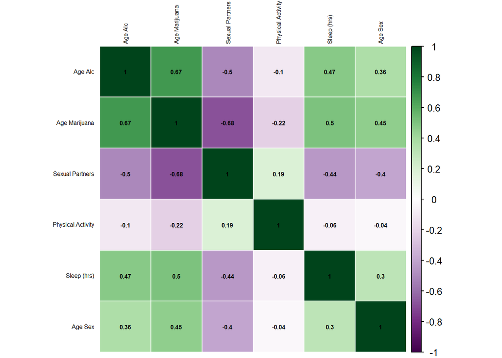

```r
# Correlation between different numerical variables of dataframe
library(corrplot)
M <- cor(data[, -c(7, 8, 9, 10)],use="pairwise.complete.obs")
colnames(M) <- c("Age Alc", "Age Marijuana", "Sexual Partners", "Physical Activity", "Sleep (hrs)", "Age Sex")
rownames(M) <- c("Age Alc", "Age Marijuana", "Sexual Partners", "Physical Activity", "Sleep (hrs)", "Age Sex")
corrplot(M, addCoef.col = 1, number.cex = .5,method = c("color"),col = COL2('PRGn'),addgrid.col = 'white',tl.col='black',tl.cex=0.5)
```

We know that a correlation matrix depicts the correlation coefficients between all the possible pairs of values in a table/dataframe. Positive correlations are displayed in green and negative correlations are in purple. Color intensity is proportional to the correlation coefficients. We see a mix of positive and negative correlations in the matrix. We see a high positive correlation between the Age when the respondent had his first alcoholic drink with Age when the respondent had his first marijuana smoke and No. of hours the respondent sleeps in a day. Also, there is a positive correlation between Age when the respondent had his first marijuana smoke with No. of hours the respondent sleeps in a day and the Age when the respondent had his first sexual experience. We see significant negative correlations of No. of sexual partners the respondent has with Age when the respondent had his first alcoholic drink, Age when the respondent had his first marijuana smoke, No. of hours the respondent sleeps in a day, and Age when the respondent had his first sexual experience.

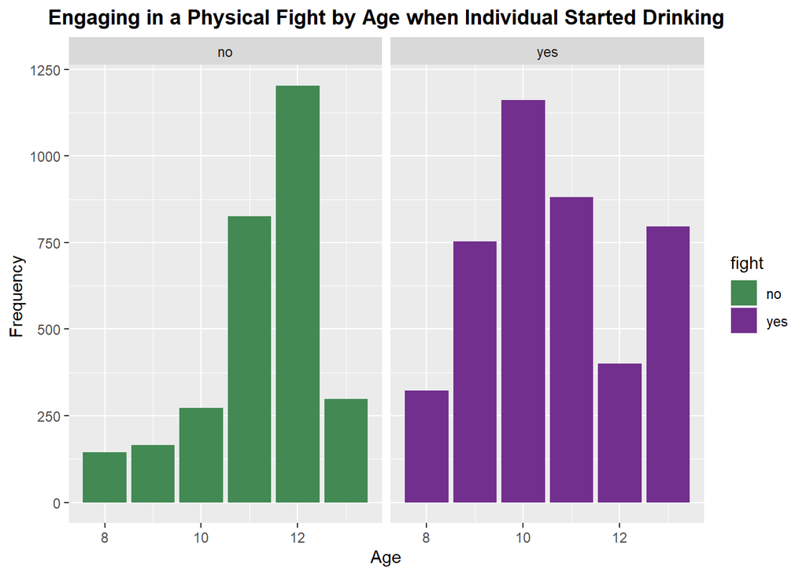

```r
colors <- c("#428953","#722f8e")

# Looking at age wehn started drinking and if ever engaged in a physical fight
ggplot(na.omit(data), aes(x = Age_Alc,fill = fight)) +
  geom_bar() +
  facet_wrap(~fight) +
  theme(plot.title = element_text(hjust = 0.5)) +
  ggtitle("Engaging in a Physical Fight by Age when Individual Started Drinking") +
  xlab("Age") +
  ylab("Frequency ") +
  theme(plot.title = element_text(face="bold",hjust = 0.5)) +
  scale_fill_manual(values=colors)
```

The figure above shows that individuals who started drinking later in adolescence (around age 11 and 12) had never engaged in a physical fight. In comparison, individuals who started drinking earlier in adolescence (between ages 9 and 10) reported engaging in a physical fight at one point in their life. The overall trends show that more individuals who drank during adolescence have gotten into a physical fight.

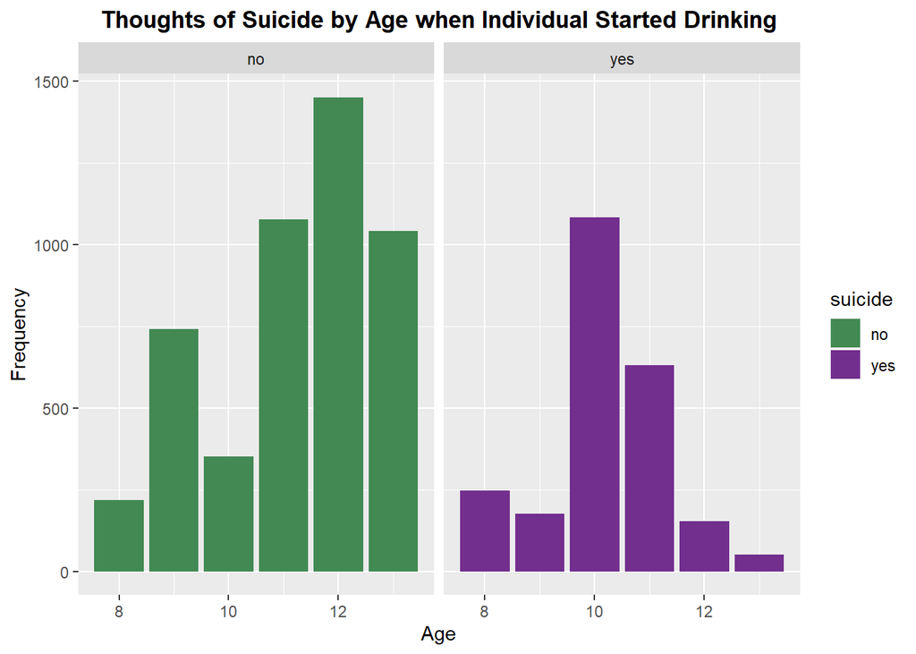

```r
#looking at age started drinking and if ever had suicidal thoughts
ggplot(na.omit(data), aes(x=Age_Alc,fill=suicide)) +
  geom_bar() +
  facet_wrap(~suicide) +
  theme(plot.title = element_text(hjust = 0.5)) +
  ggtitle("Thoughts of Suicide by Age when Individual Started Drinking") +
  xlab("Age") +
  ylab("Frequency") +
  theme(plot.title = element_text(face="bold",hjust = 0.5)) +
  scale_fill_manual(values=colors)
```

The results show that a majority of the youth have not had thoughts of committing suicide. The drinking age ranges for individuals who reported never having suicidal thoughts are more spread out with a majority reporting their first drinking experience being around ages 10 to 13. In contrast individuals who reported having thoughts of suicide cluster around age 10 which may show a potential relationship between starting drinking earlier in adolescence and having future suicidal thoughts.

```r
# T-Test
ttest2sample_alc = t.test(no_suicide$Age_Alc,yes_suicide$Age_Alc)
ttest2sample_alc
```

```
##
##  Welch Two Sample t-test
##
## data:  no_suicide$Age_Alc and yes_suicide$Age_Alc
## t = 33, df = 6030, p-value <2e-16
## alternative hypothesis: true difference in means is not equal to 0
## 95 percent confidence interval:
##  0.974 1.095
## sample estimates:
## mean of x mean of y
##      11.2      10.2
```

```r
ttest2sample_alc1 = t.test(no_fight$Age_Alc,yes_fight$Age_Alc)
ttest2sample_alc1
```

```
##
##  Welch Two Sample t-test
##
## data:  no_fight$Age_Alc and yes_fight$Age_Alc
## t = 20, df = 6987, p-value <2e-16
## alternative hypothesis: true difference in means is not equal to 0
## 95 percent confidence interval:
##  0.578 0.706
## sample estimates:
## mean of x mean of y
##      11.3      10.6
```

The results of the two sample t-test looking at the difference in average ages between individuals who have and have not had thoughts about committing suicide show that there is a significant difference in the average ages of each group. The p-value = 0.00 which means that we can accept the alternative hypothesis that there is a difference between suicidal and non-suicidal adolescents for the average age that they started drinking alcohol. The results also estimate the mean starting drinking age for non-suicidal individuals is about 11 years old while the estimated mean age for suicidal adolescents is around 10 years old when they started drinking.

Similarly, the results of the two-sample t-test looking at the difference in average ages between individuals who have and have not gotten into a physical fight show that there is a significant difference in the average ages of each group. The p-value = 0.00 which means that we can accept the alternative hypothesis that there is a difference in average starting drinking ages between individuals who have and have not engaged in a physical fight. The results also estimate the mean starting drinking age for those who have engaged in a fight to be around 10 years old and around 11 years old for those who have not engaged in a physical fight.

Overall, the results appear to show that the average starting age of drinking may be related to whether adolescents have had suicidal thoughts and have ever gotten into a physical fight. More specifically, it may be that the earlier adolescents start drinking the more likely they are to engage in these behaviors compared to adolescents who start drinking later in their life.

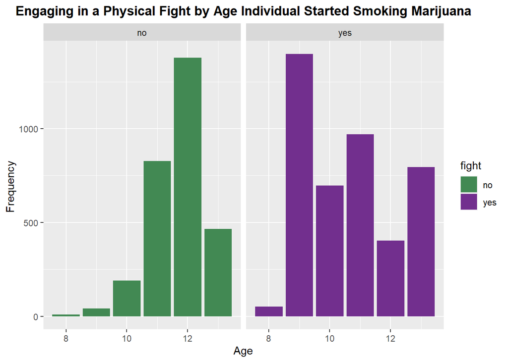

```r
#looking at age started smoking marijuana and ever engage in a physical fight
ggplot(na.omit(data), aes(x=Age_Weed,fill=fight))+
  geom_bar()+
  facet_wrap(~fight) +
  theme(plot.title = element_text(hjust = 0.5)) +
  ggtitle("Engaging in a Physical Fight by Age Individual Started Smoking Marijuana") +
  xlab("Age") +
  ylab("Frequency ") +
  theme(plot.title = element_text(face="bold",hjust = 0.5)) +
  scale_fill_manual(values=colors)
```

The results of the figure above shows that individuals who have never gotten into a physical fight started smoking marijuana later in adolescence around age 11 and 12 while a majority of individuals who have gotten into a physical fight started smoking marijuana earlier in adolescence around ages 9 to 11.

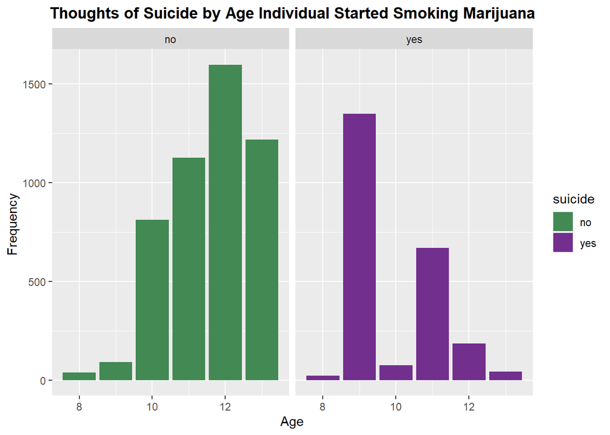

```r
#looking at age started smoking marijuana and suicidal thoughts
ggplot(na.omit(data), aes(x=Age_Weed,fill=suicide))+
  geom_bar()+
  facet_wrap(~suicide) +
  theme(plot.title = element_text(hjust = 0.5)) +
  ggtitle("Thoughts of Suicide by Age Individual Started Smoking Marijuana") +
  xlab("Age") +
  ylab("Frequency ") +
  theme(plot.title = element_text(face="bold",hjust = 0.5)) +
  scale_fill_manual(values=colors)
```

The results show that a majority of individuals have not had suicidal thoughts and the ages they started smoking marijuana ranges between 10 and 13. Interestingly, for the small majority of individuals who did report having thoughts of commiting suicide started smoking marijuana around age 9. This may reveal a potential relationship between smoking marijuana really early in adolescence and the consequences it may have on their mental health in terms of having suicidal thoughts.

```r
# T-Test
ttest2sample_weed = t.test(no_suicide$Age_Weed,yes_suicide$Age_Weed)
ttest2sample_weed
```

```
##
##  Welch Two Sample t-test
##
## data:  no_suicide$Age_Weed and yes_suicide$Age_Weed
## t = 58, df = 4482, p-value <2e-16
## alternative hypothesis: true difference in means is not equal to 0
## 95 percent confidence interval:
##  1.64 1.75
## sample estimates:
## mean of x mean of y
##      11.6       9.9
```

```r
ttest2sample_weed1 = t.test(no_fight$Age_Weed,yes_fight$Age_Weed)
ttest2sample_weed1
```

```
##
##  Welch Two Sample t-test
##
## data:  no_fight$Age_Weed and yes_fight$Age_Weed
## t = 38, df = 7115, p-value <2e-16
## alternative hypothesis: true difference in means is not equal to 0
## 95 percent confidence interval:
##  1.02 1.13
## sample estimates:
## mean of x mean of y
##      11.7      10.6
```

The results of the two sample t-test looking at the difference in average ages between individuals who have and have not had thoughts about committing suicide show that there is a significant difference in the average ages of each group. The p-value = 0.00 which means that we can accept the alternative hypothesis that there is a difference between suicidal and non-suicidal adolescents for the average age that they started smoking marijuana. The results also estimate the mean starting smoking age for non-suicidal individuals is about 11 years old while the estimated mean age for suicidal adolescents is around 10 years old for when they started smoking marijuana.

Similarly, the results of the two-sample t-test looking at the difference in average ages between individuals who have and have not gotten into a physical fight show that there is a significant difference in the average starting smoking ages of each group. The p-value = 0.00 which means that we can accept the alternative hypothesis that there is a difference in average starting smoking ages between individuals who have and have not engaged in a physical fight. The results also estimate the mean starting smoking age for those who have engaged in a fight to be around 10 years old and around 11 years old for those who have not engaged in a physical fight.

Overall, the results appear to show that the average starting age of smoking marijuana may be related to whether adolescents have had suicidal thoughts and/or have ever gotten into a physical fight. More specifically, it may be that the earlier adolescents start marijuana the more likely they may be to engage in these behaviors compared to adolescents who start smoking marijuana later in their life.

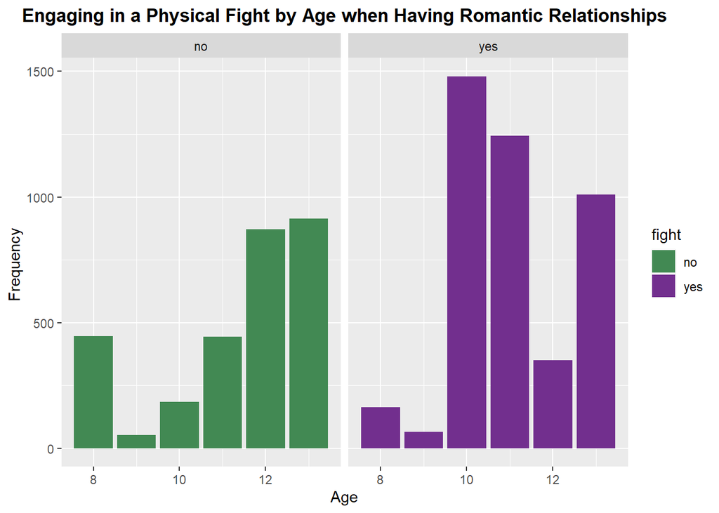

```r
#looking at age started drinking and if ever engaged in a physical fight
ggplot(na.omit(data), aes(x=age_sex,fill=fight)) +
  geom_bar() +
  facet_wrap(~fight) +
  theme(plot.title = element_text(hjust = 0.5)) +
  ggtitle("Engaging in a Physical Fight by Age when Having Romantic Relationships") +
  xlab("Age") +
  ylab("Frequency ") +
  theme(plot.title = element_text(face="bold",hjust = 0.5)) +
  scale_fill_manual(values=colors)
```

The results show that individuals who have not engaged in a physical fight reported having romantic relationships between ages 12 and 13 while individuals who have engaged in a physical fight reported having romantic relationships around 10 and 11 years old. These results may show that the later an individual starts having romantic relationships, the less likely they may be to get into physical fights and vice-versa.

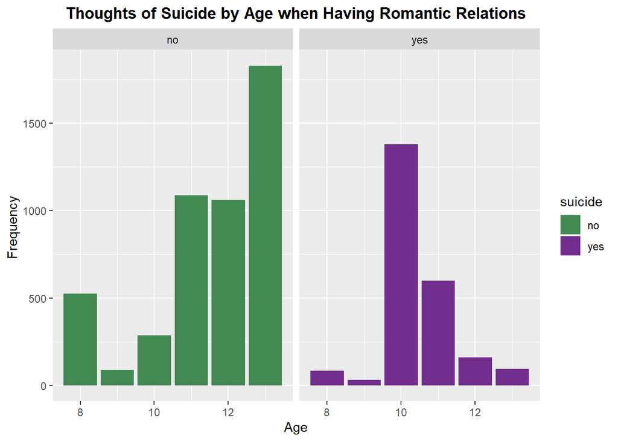

```r
#looking at age started drinking and if ever had suicidal thoughts
ggplot(na.omit(data), aes(x=age_sex, fill=suicide)) +
  geom_bar() +
  facet_wrap(~suicide) +
  theme(plot.title = element_text(hjust = 0.5)) +
  ggtitle("Thoughts of Suicide by Age when Having Romantic Relations") +
  xlab("Age") +
  ylab("Frequency ") +
  theme(plot.title = element_text(face="bold",hjust = 0.5)) +
  scale_fill_manual(values=colors)
```

The results above show that a majority of individuals who did not report having suicidal thoughts started having romantic relationships between ages 11 and 13 while a majority of individuals who did report having suicidal thoughts started having romantic relationships around age 10. The results may provide insight into how engaging in romantic relationships earlier in adolescence may lead to future suicidal thoughts for youth.

```r
# T-Test
ttest2sample_sex = t.test(no_suicide$age_sex,yes_suicide$age_sex)
ttest2sample_sex
```

```
##
##  Welch Two Sample t-test
##
## data:  no_suicide$age_sex and yes_suicide$age_sex
## t = 38, df = 6961, p-value <2e-16
## alternative hypothesis: true difference in means is not equal to 0
## 95 percent confidence interval:
##  1.06 1.18
## sample estimates:
## mean of x mean of y
##      11.5      10.4
```

```r
ttest2sample_sex1 = t.test(no_fight$age_sex,yes_fight$age_sex)
ttest2sample_sex1
```

```
##
##  Welch Two Sample t-test
##
## data:  no_fight$age_sex and yes_fight$age_sex
## t = 8, df = 5170, p-value = 3e-16
## alternative hypothesis: true difference in means is not equal to 0
## 95 percent confidence interval:
##  0.234 0.382
## sample estimates:
## mean of x mean of y
##      11.4      11.1
```

The results of the two sample t-test looking at the difference in average ages between individuals who have and have not had thoughts about committing suicide show that there is a significant difference in the average ages of each group. The p-value = 0.00 which means that we can accept the alternative hypothesis that there is a difference between suicidal and non-suicidal adolescents for the average age that they started having romantic relationships. The results also estimate the mean age for first romantic relationships for non-suicidal individuals is about 11 years old while the estimated mean age for suicidal adolescents is around 10 years old for when they started having romantic interests.

Overall, the results appear to show that the average starting age of romantic relationships may be related to whether adolescents have suicidal thoughts and/or have ever gotten into a physical fight. More specifically, it may be that the earlier adolescents start having romantic relationships the more likely they may be to engage in these behaviors compared to adolescents who have romantic interests later in their life.

```r
# Anova Test
race_vs_multipartners <- aov(multiple_partners ~ race, data =data )
xkabledply(race_vs_multipartners,"One-Way ANOVA of Average Sexual Partners between Racial Groups")
```

One-Way ANOVA of Average Sexual Partners between Racial Groups

|  | Df | Sum Sq | Mean Sq | F value | Pr(>F) |
| --- | --- | --- | --- | --- | --- |
| race | 3 | 8617 | 2872.43 | 995 | 0 |
| Residuals | 7220 | 20849 | 2.89 | NA | NA |

We ran a One-Way ANOVA in order to compare the average number of sexual partners between racial groups. Since the p-value of 0.000 is less than the significance level of 0.05, we reject the null hypothesis that there is NO difference in the average number of sexual partners an individual has between races.

```r
race_vs_physicalactivity <- aov(physical_activity ~ race, data =data )
xkabledply(race_vs_physicalactivity,"One-Way ANOVA of Average Days of Physical Activity between Racial Groups")
```

One-Way ANOVA of Average Days of Physical Activity between Racial Groups

|  | Df | Sum Sq | Mean Sq | F value | Pr(>F) |
| --- | --- | --- | --- | --- | --- |
| race | 3 | 6717 | 2239.15 | 422 | 0 |
| Residuals | 7220 | 38307 | 5.31 | NA | NA |

Similarly, our one-way ANOVA comparing the average days of physical activity between racial groups indicated that there is a statistically significant difference in the average number of days of physical activity between racial groups (p<0.05).

```r
race_vs_HrsOfSleep <- aov(Hrs_Sleep ~ race, data = data)
xkabledply(race_vs_HrsOfSleep,"One-Way ANOVA of Average Hours of Sleep between Racial Groups")
```

One-Way ANOVA of Average Hours of Sleep between Racial Groups

|  | Df | Sum Sq | Mean Sq | F value | Pr(>F) |
| --- | --- | --- | --- | --- | --- |
| race | 3 | 806 | 268.65 | 146 | 0 |
| Residuals | 7220 | 13292 | 1.84 | NA | NA |

The results of our one-way ANOVA comparing the average hours of sleep between racial groups indicates a significant difference in the average hours of sleep each racial group has per night considering p=0.00.

```r
# Recoding Race Column
data$race <- recode(data$race, '1' = 'White', '2' = 'Black or African American','3'='Hispanic/Latino','4'='All Other Races')
```

```r
# Average values of different columns for different races

agg_df <- aggregate(cbind(data$Hrs_Sleep,data$physical_activity,data$multiple_partner,data$Age_Weed,data$age_sex,data$Age_Alc) ~ data$race, FUN=mean)

colnames(agg_df) = c('Race','Hours of Sleep','Days of Physical Activity','Sexual Partners','Age Smoking Marijuana','Age Having Romantic Relations','Age Drinking Alcohol')

customGreen0 = "#DeF7E9"
customGreen = "#71CA97"
formattable(agg_df, align =c("l","c","c","c","c", "c", "r"), list(
  'Race' = formatter("span", style = ~ style(color = "dark gray",font.weight = "bold")),
  'Hours of Sleep' = color_tile(customGreen,customGreen0),
  'Days of Physical Activity'= color_tile(customGreen,customGreen0),
  'Sexual Partners'= color_tile(customGreen,customGreen0),
  'Age Smoking Marijuana'= color_tile(customGreen,customGreen0),
  'Age Having Romantic Relations'= color_tile(customGreen,customGreen0),
  'Age Drinking Alcohol'= color_tile(customGreen,customGreen0)
))
```

| Race | Hours of Sleep | Days of Physical Activity | Sexual Partners | Age Smoking Marijuana | Age Having Romantic Relations | Age Drinking Alcohol |
| --- | --- | --- | --- | --- | --- | --- |
| White | 6.32 | 3.86 | 2.85 | 11.51 | 11.4 | 11.1 |
| Black or African American | 5.52 | 6.03 | 5.23 | 9.68 | 10.3 | 10.1 |
| Hispanic/Latino | 6.26 | 5.78 | 2.64 | 11.51 | 11.6 | 11.2 |
| All Other Races | 6.11 | 3.90 | 2.71 | 11.51 | 11.0 | 11.3 |

White individuals have the greatest average hours of sleep per night around 6.3 hours while African American individuals have the lowest average hours of sleep per night around 5.5 hours. Hispanic/Latino individuals and individuals of other races have around 6.3 hours and 6.1 hours of sleep per night on average. For physical activity, White individuals and individuals of other races engage in physical activity only 3.9 days a week while African American and Hispanic/Latino individuals work out around 6 days a week on average. African American individuals have the greatest number of sexual partners (~ 5 partners) in comparison to White, Hispanic/Latino, and individuals of other races which all have had around 3 sexual partners. In addition, African American individuals have the youngest average age for smoking marijuana (~9.6 years), having romantic relationships (~10.3 years), and drinking alcohol (~10.1 years) in comparison to all other racial groups.

```r
library(janitor)
t <- tabyl(na.omit(data), race, fight)



knitr::kable(t, col.names = c('Race', 'No', 'Yes'),format = "simple",align = "lcc", caption = "Engaging in a Fight by Race") %>%
kableExtra::kable_styling(bootstrap_options = c("hover"),
                            full_width = FALSE, position = "float_left")
```

Engaging in a Fight by Race

| Race | No | Yes |
| --- | --- | --- |
| White | 1600 | 587 |
| Black or African American | 281 | 1543 |
| Hispanic/Latino | 788 | 2063 |
| All Other Races | 241 | 121 |

```r
t1 <- tabyl(na.omit(data), race, suicide)



knitr::kable(t1,col.names = c('Race', 'No', 'Yes'),format = "simple",align = "lcc", caption = "Suicidal Thoughts by Race")%>%
kableExtra::kable_styling(bootstrap_options = c("hover"),
                          full_width = FALSE, position = "float_right")
```

Suicidal Thoughts by Race

| Race | No | Yes |
| --- | --- | --- |
| White | 1933 | 254 |
| Black or African American | 419 | 1405 |
| Hispanic/Latino | 2239 | 612 |
| All Other Races | 289 | 73 |

When looking at whether or not individuals have engaged in a physical fight and had thoughts of suicide between races we can see that African American and Hispanic/Latino individuals reported engaging in a fight more than not. They both had around 1200 more individuals report being in a physical fight than those who have not. In contrast, a majority of White individuals and individuals of other races reported never engaging in a physical fight compared to those who have. In regards to reporting suicidal thoughts, the only group that had more individuals report having had suicidal thoughts than those who have not were African American/Black individuals. There were about 1000 more African American/Black individuals who reported having suicidal thoughts than those who have not. For White, Hispanic/Latino, and individuals of other races a majority of people reported never having thoughts of suicide. These results indicate that race may play a crucial role in behavioral and emotional well-being for adolescents. The average hour of sleep by white race is 6.32 hours which is highest among the all the races whereas the average hour of sleep by Hispanic/Latino and Black or African American are 6.26 and 5.516 hours. All other Races sleep 6.11 average hour of sleep.

## Modeling Engagement in a Physical Fight

### Logistic Regression Predicting Engagement in a Physical Fight

```r
# Recoding Dataset
data$fight1 <- recode(data$fight, 'yes' = 1, 'no' = 0)
data$suicide1 <- recode(data$suicide, 'yes' = 1, 'no' = 0)
#data$fight1 <- recode(data$fight, '0' = 1, '1' = 0)
#data$suicide1 <- recode(data$suicide, '0' = 1, '1' = 0)
data$suicide1 <- as.factor(data$suicide1)
data$fight1 <- as.factor(data$fight1)
```

```r
# Making Training and Testing Dataset
set.seed(920)
sample <- sample(c(TRUE, FALSE), nrow(data), replace=TRUE, prob=c(0.8,0.2))
traindata1  <- data[sample, ]
testdata1   <- data[!sample, ]
```

```r
# Logistic Regression Model
model1a<-glm(formula = fight1 ~ Age_Weed + Age_Alc + age_sex + race , family = "binomial", data = traindata1)
summary(model1a)
```

```
##
## Call:
## glm(formula = fight1 ~ Age_Weed + Age_Alc + age_sex + race, family = "binomial",
##     data = traindata1)
##
## Deviance Residuals:
##    Min      1Q  Median      3Q     Max
## -2.832  -0.745   0.428   0.680   2.366
##
## Coefficients:
##                               Estimate Std. Error z value Pr(>|z|)
## (Intercept)                     4.9049     0.3609   13.59  < 2e-16 ***
## Age_Weed                       -0.7520     0.0386  -19.46  < 2e-16 ***
## Age_Alc                         0.0832     0.0303    2.75    0.006 **
## age_sex                         0.1524     0.0240    6.36  2.1e-10 ***
## raceBlack or African American   1.8484     0.1014   18.23  < 2e-16 ***
## raceHispanic/Latino             2.1218     0.0763   27.82  < 2e-16 ***
## raceAll Other Races             0.3097     0.1454    2.13    0.033 *
## ---
## Signif. codes:  0 '***' 0.001 '**' 0.01 '*' 0.05 '.' 0.1 ' ' 1
##
## (Dispersion parameter for binomial family taken to be 1)
##
##     Null deviance: 7829.1  on 5802  degrees of freedom
## Residual deviance: 5855.1  on 5796  degrees of freedom
## AIC: 5869
##
## Number of Fisher Scoring iterations: 4
```

```r
# Confusion Matrix
testdata1$modelPredicted1a <- predict(model1a, newdata = testdata1, type = 'response')
confusionMatrix(as.factor(as.numeric(testdata1$modelPredicted1a>0.55)), testdata1$fight1)
```

```
## Confusion Matrix and Statistics
##
##           Reference
## Prediction   0   1
##          0 396 141
##          1 170 714
##
##                Accuracy : 0.781
##                  95% CI : (0.759, 0.802)
##     No Information Rate : 0.602
##     P-Value [Acc > NIR] : <2e-16
##
##                   Kappa : 0.539
##
##  Mcnemar's Test P-Value : 0.112
##
##             Sensitivity : 0.700
##             Specificity : 0.835
##          Pos Pred Value : 0.737
##          Neg Pred Value : 0.808
##              Prevalence : 0.398
##          Detection Rate : 0.279
##    Detection Prevalence : 0.378
##       Balanced Accuracy : 0.767
##
##        'Positive' Class : 0
##
```

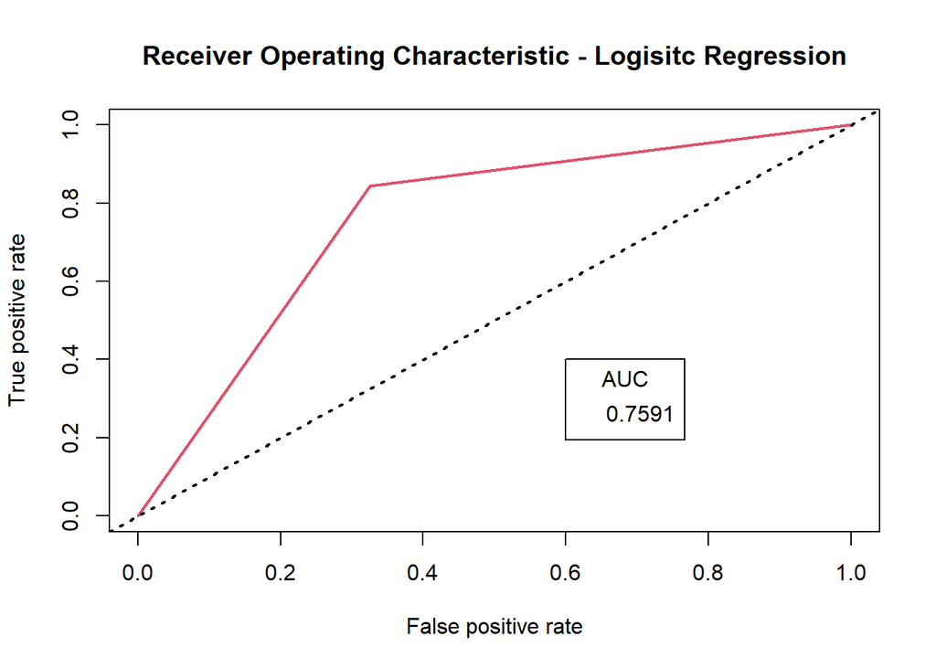

```r
# ROC-AUC Curve
ROCPred <- prediction(predict_reg, testdata1$fight1)
ROCPer <- performance(ROCPred, measure = "tpr",
                             x.measure = "fpr")

auc <- performance(ROCPred, measure = "auc")
auc <- auc@y.values[[1]]


# Plotting curve
plot(ROCPer,main = "Receiver Operating Characteristic - Logisitc Regression",col = 2,lwd = 2)
abline(a = 0,b = 1,lwd = 2,lty = 3,col = "black")

auc <- round(auc, 4)
legend(.6, .4, auc, title = "AUC", cex = 1)
```

When looking at the shape of relative operating characteristic (ROC) curve, we can see that the performance of the logistic regression classifier model is pretty good. Since the curve is towards the upper left corner, we know the more efficient our test being performed will be. In addition, the area under the curve (AUC) is high at 0.75 which means that the model is good at distinguishing between engaging in a fight and not engaging in a fight.

### Decision Tree Regression Predicting Engagement in a Physical Fight

```r
# Making factor for Race Column
data$race <- as.factor(data$race)
set.seed(920)

sample <- sample(c(TRUE, FALSE), nrow(data), replace=TRUE, prob=c(0.8,0.2))
traindata1  <- data[sample, ]
testdata1   <- data[!sample, ]

model1b<-rpart(formula = fight1 ~ Age_Weed + Age_Alc + age_sex + race , data = traindata1, method = 'class',minsplit = 5, minbucket = 5)
```

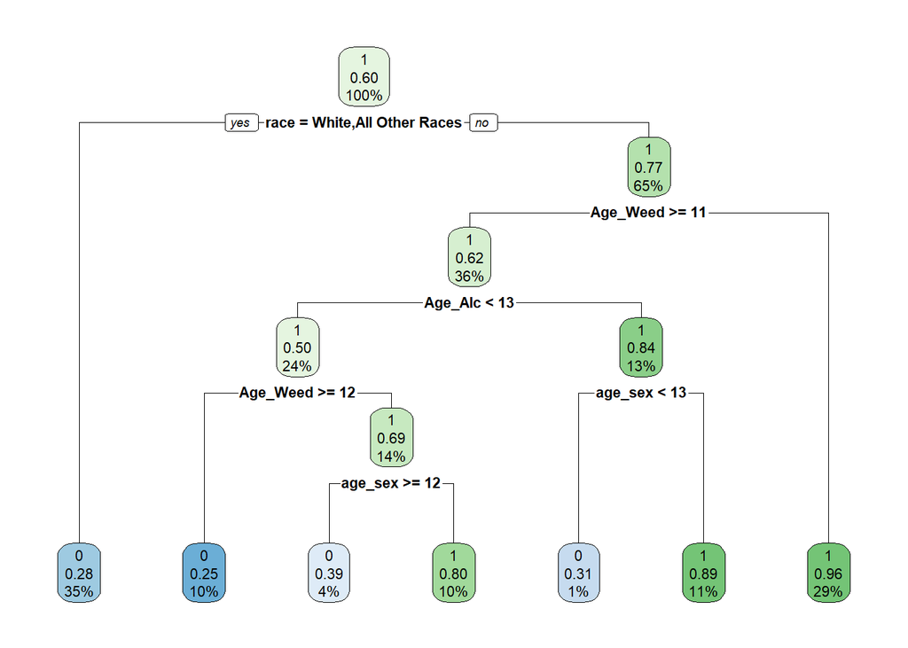

```r
rpart.plot(model1b, extra = 106)
```

```r
testdata1$modelPredicted1b <-predict(model1b, testdata1, type = 'class')
table1b <- confusionMatrix(testdata1$modelPredicted1b, testdata1$fight1, positive='1')
table1b
```

```
## Confusion Matrix and Statistics
##
##           Reference
## Prediction   0   1
##          0 503 207
##          1  63 648
##
##                Accuracy : 0.81
##                  95% CI : (0.789, 0.83)
##     No Information Rate : 0.602
##     P-Value [Acc > NIR] : <2e-16
##
##                   Kappa : 0.62
##
##  Mcnemar's Test P-Value : <2e-16
##
##             Sensitivity : 0.758
##             Specificity : 0.889
##          Pos Pred Value : 0.911
##          Neg Pred Value : 0.708
##              Prevalence : 0.602
##          Detection Rate : 0.456
##    Detection Prevalence : 0.500
##       Balanced Accuracy : 0.823
##
##        'Positive' Class : 1
##
```

```r
printcp(model1b)
```

```
##
## Classification tree:
## rpart(formula = fight1 ~ Age_Weed + Age_Alc + age_sex + race,
##     data = traindata1, method = "class", minsplit = 5, minbucket = 5)
##
## Variables actually used in tree construction:
## [1] Age_Alc  age_sex  Age_Weed race
##
## Root node error: 2344/5803 = 0.4
##
## n= 5803
##
##     CP nsplit rel error xerror xstd
## 1 0.38      0       1.0    1.0 0.02
## 2 0.04      1       0.6    0.6 0.01
## 3 0.02      4       0.5    0.5 0.01
## 4 0.01      5       0.5    0.5 0.01
## 5 0.01      6       0.5    0.5 0.01
```

According to the rules of the decision tree classifier, the overall probability of fighting is 60%. More specifically the rules of the decision tree indicate that African American or Hispanic/Latino individuals who start smoking marijuana at or beyond age 12 and start drinking alcohol before the age of 13 have a probability of fighting of 0.25 (about 10% of adolescents in the sample fall under this rule). White individuals and individuals of all other races have a probability of fighting of about 0.28 (35% of adolescents in the sample fall under this rule). Individuals that are African American or Hispanic/Latino, started smoking at age 11 or older, started drinking at age 13 or older, and had romantic relations before the age of 13 have a fighting probability of 0.31 (1% of the sample fall under this rule). African American or Latino/Hispanic individuals who started smoking marijuana between the ages of 11 and 12, started drinking before the age of 13, and had romantic relations at or after the age of 12 have a fighting probability of 0.39 (4% of the sample fall under this rule). African American or Latino/Hispanic individuals who started smoking marijuana between the ages of 11 and 12, started drinking before the age of 13, and had romantic relations before 12 years old have a fighting probability of 0.80 (10% of the sample fall under this rule). African American or Latino/Hispanic individuals who started smoking marijuana after age 11, started drinking at or after the age of 13, and had romantic relations at or after the age of 13 have a fighting probability of 0.89 (11% of the sample fall under this rule). Lastly, individuals that are African American or Hispanic/Latino and started smoking marijuana before 11 years old have a probability of fighting of 0.96 (29% of individuals fall under this rule).

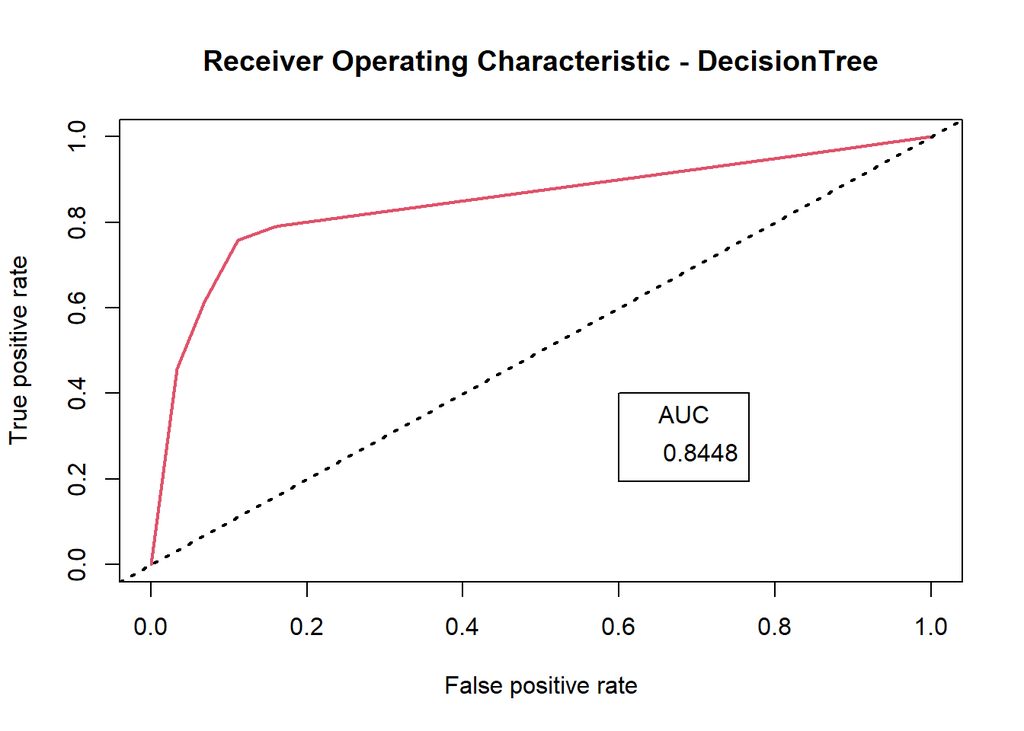

```r
DTPrediction <- predict(model1b, testdata1,type = "prob")
Prediction <- prediction(DTPrediction[,2],testdata1$fight1)
performance <- performance(Prediction, "tpr","fpr")

# plotting ROC curve
plot(performance,main = "Receiver Operating Characteristic - DecisionTree",col = 2,lwd = 2)
abline(a = 0,b = 1,lwd = 2,lty = 3,col = "black")

#AUC
DTPrediction <- prediction(DTPrediction[,2],testdata1$fight1)
aucDT <- performance(DTPrediction, measure = "auc")
aucDT <- aucDT@y.values[[1]]
auc <- round(aucDT, 4)
legend(.6, .4, auc, title = "AUC", cex = 1)
```

When looking at the shape of relative operating characteristic (ROC) curve, we can see that the performance of the decision tree classifier model is very good. Since the curve is towards the upper left corner, we know the more efficient our test being performed will be. In addition, the area under the curve (AUC) is even higher than the logistic regression classifier at 0.84 which means that the model is good at distinguishing between engaging in a fight and not engaging in a fight.

### Random Forest Classifying Engagement in a Physical Fight

```r
set.seed(920)
sample <- sample(c(TRUE, FALSE), nrow(data), replace=TRUE, prob=c(0.8,0.2))
traindata1  <- data[sample, ]
testdata1   <- data[!sample, ]
```

```r
model1c<-randomForest(formula = fight1 ~ Age_Weed + Age_Alc + age_sex + race , data = traindata1, proximity=TRUE, type='classification', na.action=na.exclude)
print(model1c)
```

```
##
## Call:
##  randomForest(formula = fight1 ~ Age_Weed + Age_Alc + age_sex +      race, data = traindata1, proximity = TRUE, type = "classification",      na.action = na.exclude)
##                Type of random forest: classification
##                      Number of trees: 500
## No. of variables tried at each split: 2
##
##         OOB estimate of  error rate: 15.6%
## Confusion matrix:
##      0    1 class.error
## 0 2086  258       0.110
## 1  649 2810       0.188
```

```r
testdata1$modelPredicted1c <-predict(model1c, testdata1)
confusionMatrix(testdata1$fight1, testdata1$modelPredicted1c)
```

```
## Confusion Matrix and Statistics
##
##           Reference
## Prediction   0   1
##          0 510  56
##          1 170 685
##
##                Accuracy : 0.841
##                  95% CI : (0.821, 0.86)
##     No Information Rate : 0.521
##     P-Value [Acc > NIR] : < 2e-16
##
##                   Kappa : 0.679
##
##  Mcnemar's Test P-Value : 5.62e-14
##
##             Sensitivity : 0.750
##             Specificity : 0.924
##          Pos Pred Value : 0.901
##          Neg Pred Value : 0.801
##              Prevalence : 0.479
##          Detection Rate : 0.359
##    Detection Prevalence : 0.398
##       Balanced Accuracy : 0.837
##
##        'Positive' Class : 0
##
```

The accuracy of the random forest model used to predict engagement in a physical fight from race, age when an individual first drank alcohol, smoked marijuana, and had romantic relationships is about 84%.

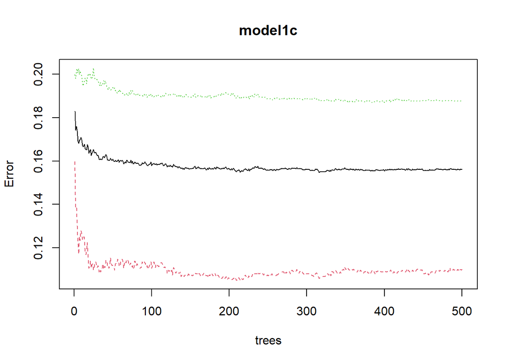

```r
plot(model1c)
```

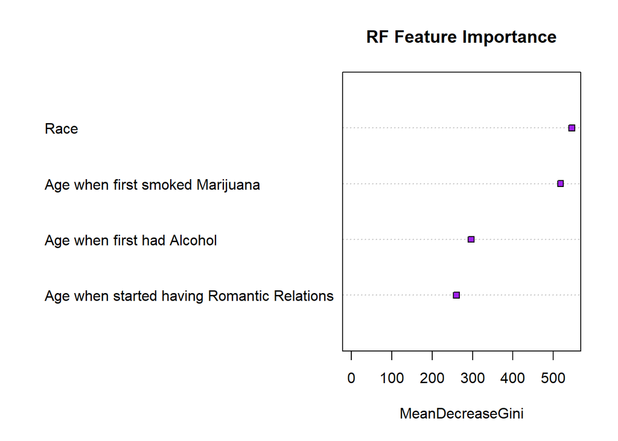

```r
varImpPlot(model1c, bg = "purple", cex=1, pch=22, main="RF Feature Importance", labels = c("Age when started having Romantic Relations", "Age when first had Alcohol", "Age when first smoked Marijuana", "Race"))
```

If you drop Race and Age when first smoked Marijuana from the model, it’s prediction power will greatly reduce. On the other hand if we reduce one of the bottom variables i.e. Age when first had alcohol and Age when started having romantic relations, there might be some impact on prediction power of the model.

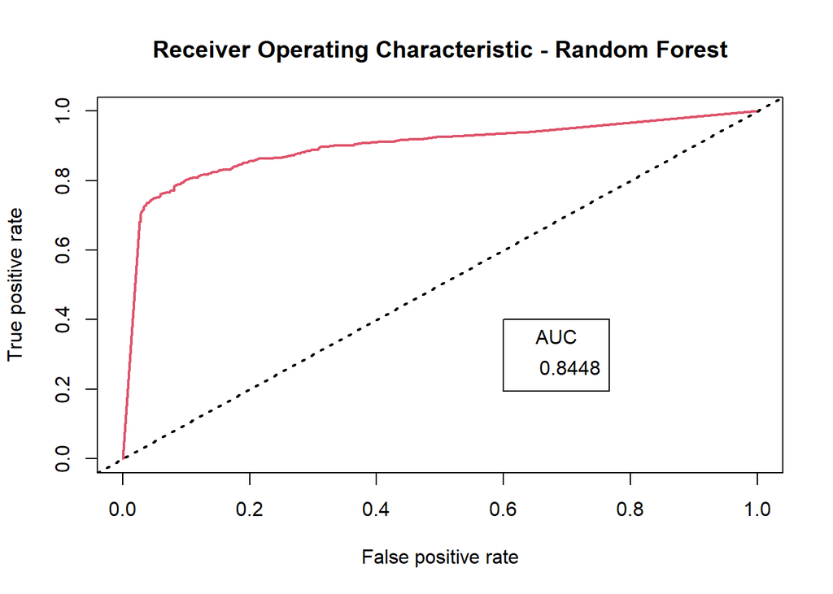

```r
### plotting ROC curve and calculating AUC metric
DTPrediction1 <- predict(model1c, testdata1,type = "prob")
Prediction <- prediction(DTPrediction1[,2],testdata1$fight1)
performance <- performance(Prediction, "tpr","fpr")

# plotting ROC curve
plot(performance,main = "Receiver Operating Characteristic - Random Forest",col = 2,lwd = 2)
abline(a = 0,b = 1,lwd = 2,lty = 3,col = "black")
auc <- round(aucDT, 4)
legend(.6, .4, auc, title = "AUC", cex = 1)
```

```r
#AUC
DTPrediction1 <- prediction(DTPrediction1[,2],testdata1$fight1)
aucDT <- performance(DTPrediction1, measure = "auc")
aucDT <- aucDT@y.values[[1]]
```

## Modeling Thoughts of Suicide

### Logistic Regression Predicting Suicidal Thoughts

```r
set.seed(927)
sample <- sample(c(TRUE, FALSE), nrow(data), replace=TRUE, prob=c(0.8,0.2))
traindata2  <- data[sample, ]
testdata2   <- data[!sample, ]
```

```r
model2a<-glm(formula = suicide1 ~ Age_Weed + Age_Alc + age_sex + race , family = "binomial", data = traindata2)
summary(model2a)
```

```
##
## Call:
## glm(formula = suicide1 ~ Age_Weed + Age_Alc + age_sex + race,
##     family = "binomial", data = traindata2)
##
## Deviance Residuals:
##    Min      1Q  Median      3Q     Max
## -2.508  -0.605  -0.335   0.489   2.838
##
## Coefficients:
##                               Estimate Std. Error z value Pr(>|z|)
## (Intercept)                     8.3067     0.4298   19.33  < 2e-16 ***
## Age_Weed                       -0.8158     0.0418  -19.50  < 2e-16 ***
## Age_Alc                         0.1343     0.0349    3.85  0.00012 ***
## age_sex                        -0.2452     0.0277   -8.86  < 2e-16 ***
## raceBlack or African American   2.2077     0.1123   19.66  < 2e-16 ***
## raceHispanic/Latino             0.8902     0.0984    9.05  < 2e-16 ***
## raceAll Other Races             0.6374     0.1770    3.60  0.00032 ***
## ---
## Signif. codes:  0 '***' 0.001 '**' 0.01 '*' 0.05 '.' 0.1 ' ' 1
##
## (Dispersion parameter for binomial family taken to be 1)
##
##     Null deviance: 7255.5  on 5782  degrees of freedom
## Residual deviance: 4648.2  on 5776  degrees of freedom
## AIC: 4662
##
## Number of Fisher Scoring iterations: 5
```

```r
testdata2$modelPredicted2a <- predict(model2a, newdata = testdata2, type = 'response')
confusionMatrix(as.factor(as.numeric(testdata2$modelPredicted2a>0.55)), testdata2$suicide1)
```

```
## Confusion Matrix and Statistics
##
##           Reference
## Prediction   0   1
##          0 902 184
##          1  49 306
##
##                Accuracy : 0.838
##                  95% CI : (0.818, 0.857)
##     No Information Rate : 0.66
##     P-Value [Acc > NIR] : <2e-16
##
##                   Kappa : 0.614
##
##  Mcnemar's Test P-Value : <2e-16
##
##             Sensitivity : 0.948
##             Specificity : 0.624
##          Pos Pred Value : 0.831
##          Neg Pred Value : 0.862
##              Prevalence : 0.660
##          Detection Rate : 0.626
##    Detection Prevalence : 0.754
##       Balanced Accuracy : 0.786
##
##        'Positive' Class : 0
##
```

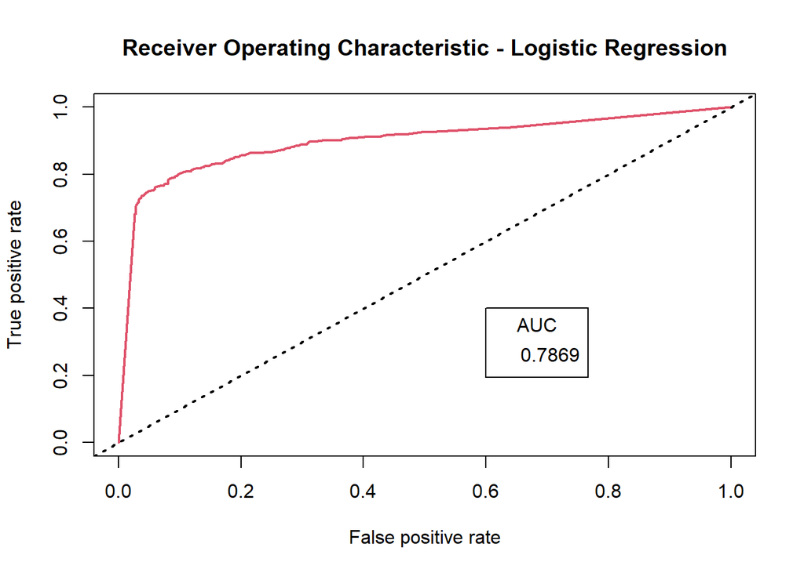

```r
# ROC-AUC Curve
ROCPred <- prediction(predict_reg, testdata2$suicide1)
ROCPer <- performance(ROCPred, measure = "tpr",
                             x.measure = "fpr")

auc <- performance(ROCPred, measure = "auc")
auc <- auc@y.values[[1]]

# Plotting curve
plot(performance,main = "Receiver Operating Characteristic - Logistic Regression",col = 2,lwd = 2)
abline(a = 0,b = 1,lwd = 2,lty = 3,col = "black")

auc <- round(auc, 4)
legend(.6, .4, auc, title = "AUC", cex = 1)
```

### Decision Tree Classifying Suicidal Thoughts

```r
set.seed(927)
sample <- sample(c(TRUE, FALSE), nrow(data), replace=TRUE, prob=c(0.8,0.2))
traindata2  <- data[sample, ]
testdata2   <- data[!sample, ]
```

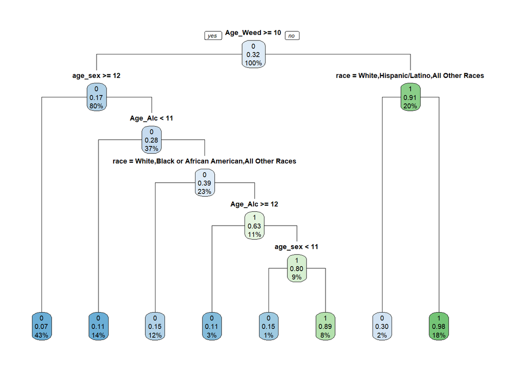

```r
model2b<-rpart(formula = suicide1 ~ Age_Weed + Age_Alc + age_sex + race , data = traindata2, method = 'class')
rpart.plot(model2b, extra = 106, type = 1)
```

```r
testdata2$modelPredicted2b <-predict(model2b, testdata2, type = 'class')
table2b <- confusionMatrix(testdata2$modelPredicted2b, testdata2$suicide1, positive='1')
table2b
```

```
## Confusion Matrix and Statistics
##
##           Reference
## Prediction   0   1
##          0 938 133
##          1  13 357
##
##                Accuracy : 0.899
##                  95% CI : (0.882, 0.914)
##     No Information Rate : 0.66
##     P-Value [Acc > NIR] : <2e-16
##
##                   Kappa : 0.76
##
##  Mcnemar's Test P-Value : <2e-16
##
##             Sensitivity : 0.729
##             Specificity : 0.986
##          Pos Pred Value : 0.965
##          Neg Pred Value : 0.876
##              Prevalence : 0.340
##          Detection Rate : 0.248
##    Detection Prevalence : 0.257
##       Balanced Accuracy : 0.857
##
##        'Positive' Class : 1
##
```

```r
printcp(model2b)
```

```
##
## Classification tree:
## rpart(formula = suicide1 ~ Age_Weed + Age_Alc + age_sex + race,
##     data = traindata2, method = "class")
##
## Variables actually used in tree construction:
## [1] Age_Alc  age_sex  Age_Weed race
##
## Root node error: 1854/5783 = 0.3
##
## n= 5783
##
##     CP nsplit rel error xerror xstd
## 1 0.52      0       1.0    1.0 0.02
## 2 0.03      1       0.5    0.5 0.01
## 3 0.03      5       0.3    0.4 0.01
## 4 0.02      6       0.3    0.3 0.01
## 5 0.01      7       0.3    0.3 0.01
```

The rules of the decision tree classifier indicate that adolescents who start smoking marijuana after the age of 10 and have romantic relationships after the age of 12 have a 0.07 chance of being suicidal. For individuals who start smoking marijuana at or after age 10, have romantic relationships before age 12, and have alcohol before age 11 have a 0.11 probability of being suicidal. Similarly, Hispanic/Latino individuals who start smoking marijuana at or after age 10, have romantic relationships before age 12, and drink alcohol at or after age 12 have a 0.11 probability of being suicidal. Hispanic/Latino individuals who have romantic relationships before age 11, smoke marijuana at or after age 10, and drink alcohol between 11 and 12 years old have a 0.15 chance of being suicidal. White, African American, and all other race individuals who smoke marijuana at or after age 10, have romantic relationships before age 12, and drink alcohol at or after 11 years old have a 0.15 probability of being suicidal. White, Hispanic/Latino, and other race individuals who smoke marijuana before age 10 have a 0.30 chance of being suicidal. Hispanic/Latino individuals who have romantic relationships and drink alcohol between 11 and 12 years old and who smoke marijuana after the age of 10 have a 0.89 probability of being suicidal. Lastly, Black/African American individuals who smoke marijuana before the age of 10 have a 0.98 probability of being suicidal.

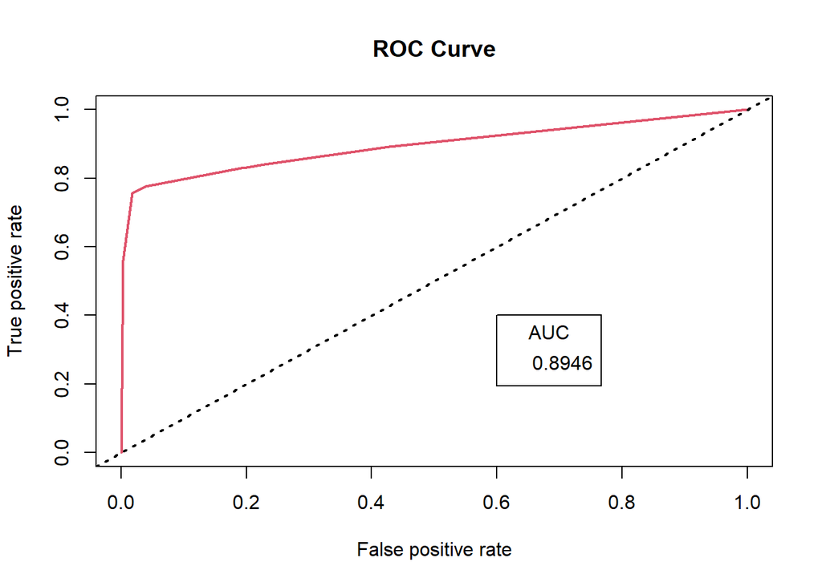

```r
### plotting ROC curve and calculating AUC metric
DTPrediction <- predict(model2b, testdata1,type = "prob")
Prediction <- prediction(DTPrediction[,2],testdata1$suicide1)
performance <- performance(Prediction, "tpr","fpr")

# plotting ROC curve
plot(performance,main = "ROC Curve",col = 2,lwd = 2)
abline(a = 0,b = 1,lwd = 2,lty = 3,col = "black")

#AUC
DTPrediction <- prediction(DTPrediction[,2],testdata1$suicide1)
aucDT <- performance(DTPrediction, measure = "auc")
aucDT <- aucDT@y.values[[1]]

auc <- round(aucDT, 4)
legend(.6, .4, auc, title = "AUC", cex = 1)
```

The ROC curve is towards the upper left corner which means that the performance of the decision tree classifier model is very efficient. In addition, the area under the curve (AUC) is 0.89 which means that the model is very good at distinguishing between whether or not an adolescent is suicidal.